# Chi Squared Test

```r
library(haven)
library(tidyverse)
library(pander)

mytable <- rbind("Less than HS" = c(Married=87, Divorced=44, "Never Married"=77, Separated = 12, Widowed = 26),
                 HS  = c(695,314,385,52,144),
                 Associates = c(172,75,94,5,24),
                 Bachelors=c(557,130,269,15,63),
                 Graduate = c(477,90,140,10,43))
#pander(mytable)

#table(gss2021$GOODLIFE,gss2021$BIBLEV)

# Martital
# DEGREE




#mychi$expected # we want all counts to be greater than 5
#mychi$residuals # see below

# where there is a really big residual, we see more people in that category
# than expected, it's more of a prediction
```

## Background

Data was drawn from a survey in which people were asked a variety of questions for the General Social Survey (GSS). Among these questions, those in the survey were directly asked, “If finished 9th-12th grade: Did you ever get a high school diploma or a GED certificate?” (which is displayed in the rows in the table below) and “Are you currently – married, widowed, divorced, separated, or have you never been married?” which is displayed in the columns in the table below.

## Hypothesis

The interest is in seeing if there is an association between both questions, or in other words: Is there an association between the academic `degree` earned and the `marital status` of a person?

The hypothesis will be formally written as followed:

$$H_{0}:\ \text{Degree and Marital Status are independent.}$$
$$H_{a}:\ \text{Degree and Marital Status are associated.}$$
The significance level of the test will also be measured below:
$$\alpha = 0.05$$

## The Data

```r
pander(mytable)
```

|  | Married | Divorced | Never Married | Separated | Widowed |
| --- | --- | --- | --- | --- | --- |
| **Less than HS** | 87 | 44 | 77 | 12 | 26 |
| **HS** | 695 | 314 | 385 | 52 | 144 |
| **Associates** | 172 | 75 | 94 | 5 | 24 |
| **Bachelors** | 557 | 130 | 269 | 15 | 63 |
| **Graduate** | 477 | 90 | 140 | 10 | 43 |

The data is further displayed below on the bar plot. The pattern of `degrees` seems to have a similar shape across each `marital status` type. However, the frequency of each `degree` changes dramatically across each `marital type`. The “Married” and “Never Married” `marital types` appear to have the most frequencies of all `degrees` overall with the “Separated” and “Widowed” `marital types` with the lowest frequencies overall. In each group the pattern looks the same, with “HS”, “Bachelors”, and “Graduate” descending in each `marital type` from highest to lowest frequency. Initially, it appears that there is an association between `degree` and `marital status`. In order to test if both factors are associated, a chi-squared test will be run below.

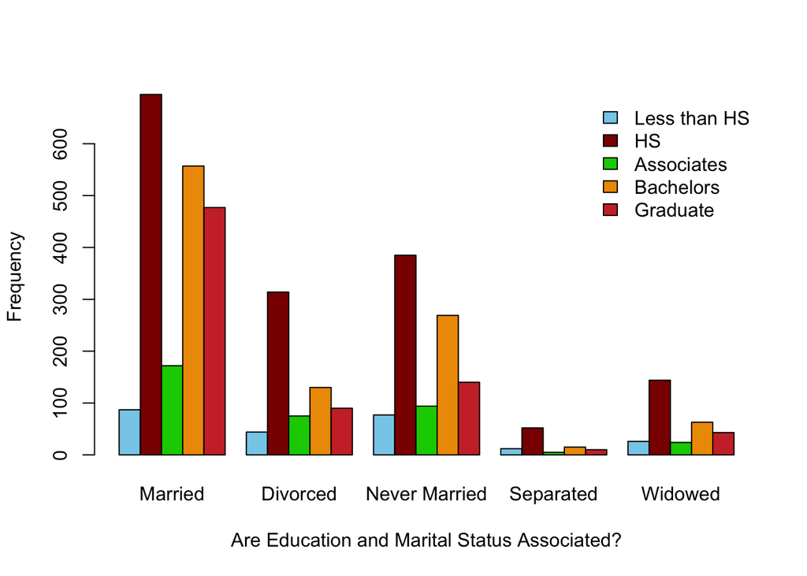

```r
barplot(mytable, beside=TRUE,
        legend.text = TRUE,
        args.legend = list(x="topright", bty="n"),
        col=c("skyblue","red4","green3","orange2","brown3"),
        ylab="Frequency",
        xlab="Are Education and Marital Status Associated?")
```

## Chi-Squared Test

In order to determine if `degree` and `marital status` are independent or if they are associated, the Chi-Squared test will be run below.

```r
mychi <- chisq.test(mytable)
pander(mychi)
```

Pearson’s Chi-squared test: `mytable`

| Test statistic | df | P value |
| --- | --- | --- |
| 138.9 | 16 | 1.178e-21 * * * |

With a p-value (1.178e-21) being less than the significance level of the test (0.05) we will reject the null hypothesis. In other words, `Degree` and `Marital Status` are associated according to the results of the test. However to conclude this, we will also ensure that the interpretation and fit of the test are appropriate in order to the conclude that this test was significant.

## Expected Counts

As we consider the interpretation and fit of the Chi-Squared test, we are looking to ensure that each expected count in the table below is greater than 5. Since every value in the expected counts is greater than 5, we can assume that it is an appropriate fit and interpretation for the test. (Note: The original table and counts of the test are found below the expected counts to compare the values)

```r
pander(mychi$expected)
```

|  | Married | Divorced | Never Married | Separated | Widowed |
| --- | --- | --- | --- | --- | --- |
| **Less than HS** | 122.3 | 40.16 | 59.35 | 5.781 | 18.45 |
| **HS** | 790.2 | 259.6 | 383.6 | 37.37 | 119.2 |
| **Associates** | 183.9 | 60.4 | 89.26 | 8.695 | 27.75 |
| **Bachelors** | 513.9 | 168.8 | 249.5 | 24.3 | 77.55 |
| **Graduate** | 377.7 | 124.1 | 183.3 | 17.86 | 57 |

```r
pander(mytable)
```

|  | Married | Divorced | Never Married | Separated | Widowed |
| --- | --- | --- | --- | --- | --- |
| **Less than HS** | 87 | 44 | 77 | 12 | 26 |
| **HS** | 695 | 314 | 385 | 52 | 144 |
| **Associates** | 172 | 75 | 94 | 5 | 24 |
| **Bachelors** | 557 | 130 | 269 | 15 | 63 |
| **Graduate** | 477 | 90 | 140 | 10 | 43 |

## Residuals

Continually, since the p-value is so low it is recommended that we look at the residuals to see how far away the observed counts are from the expected counts. The residuals display the distance between the observed and expected counts. The further the values are from 0, the greater distance there is between both counts.

```r
pander(mychi$residuals)
```

|  | Married | Divorced | Never Married | Separated | Widowed |
| --- | --- | --- | --- | --- | --- |
| **Less than HS** | -3.189 | 0.606 | 2.291 | 2.587 | 1.758 |
| **HS** | -3.388 | 3.379 | 0.07212 | 2.394 | 2.266 |
| **Associates** | -0.8768 | 1.878 | 0.5014 | -1.253 | -0.7119 |
| **Bachelors** | 1.901 | -2.986 | 1.238 | -1.886 | -1.652 |
| **Graduate** | 5.108 | -3.059 | -3.201 | -1.86 | -1.854 |

As shown above we can see that the greatest difference between the count that was observed and the count that was expected comes from the “Married” and “Graduate” group with a residual of 5.108. The rest of the residuals seem to range between -3.388 and 3.379 which shows that the counts of each `marital status` seems to change significantly among each `degree` type.

## Conclusion

Given the results of the Chi-Squared test and checking the appropriate fit and interpretation of the test, we can conclude that `marital status` and `degree` are associated. It could interesting to see further studies done on the association of both factors because it could be possible that there is a direct causation from one factor to another. It is also recommended that this test is replicated with further populations to ensure that the conclusions of this test are significant.